# Survey of Machine Learning Methods and Resources

10/28/2019

## Machine Learning Next Steps

– Machine learning challenges and opportunities

– Other machine learning techniques

– Machine learning resources

Friday 8:30 Grand Ballroom C, Human in Focus: Feature research and application of ubiquitous user monitoring

## Machine Learning Challenges and Opportunities

### Issues that behavioral scientists can help address

– Representative sampling

– Differential costs of prediction errors

– Tradeoff of model understandability and performance

– Explaining model output (LIME)

– Ethical considerations

– Design thinking and systems thinking

## Machine Learning Techniques

### Text analysis: Quantitative analysis of qualitative data

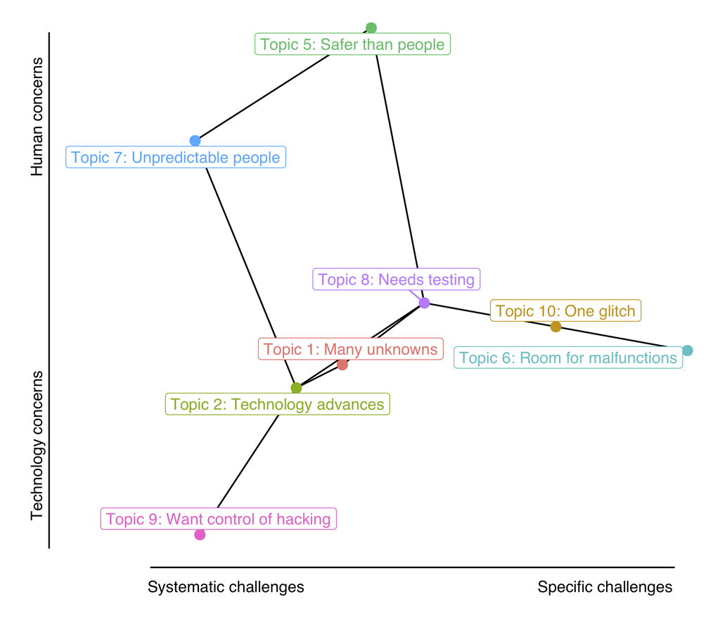

Lee, J. D., & Kolodge, K. (2019). Exploring trust in self-driving vehicles with text analysis. Human Factors.

## Machine Learning Techniques

### Visualizing multidimensional data

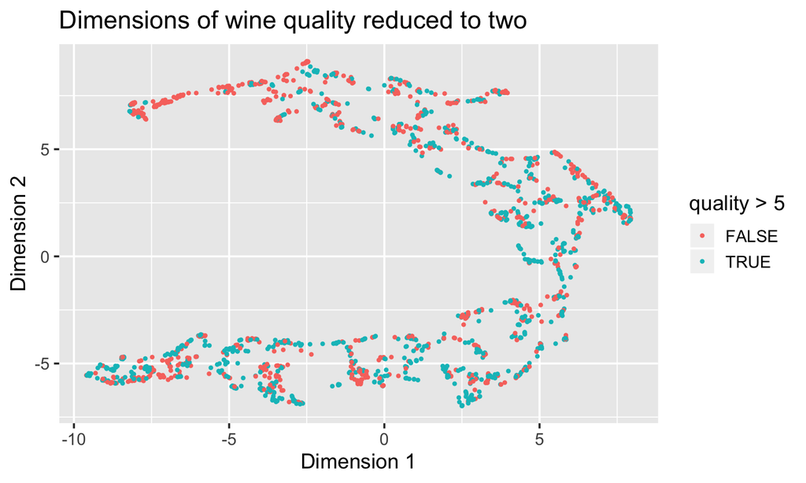

## Machine learning resources: caret

– Comprehenvise online description of caret features (http://topepo.github.io/caret/index.html)

– Early draft of book on feature engineering by the author of caret (http://www.feat.engineering)

[figure not shown]

## Machine Learning Resources: Keras

– Simple interface to powerful deep learning algorithms

– Support for prototyping through deployment

– Implement and deply in an afternoon

[figure not shown]

https://keras.rstudio.com

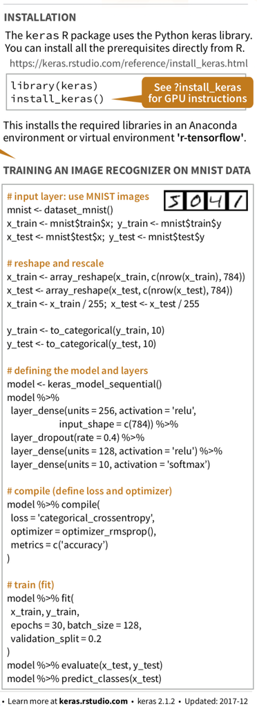

## Machine Learning Resources: Kaggle

– Data–over 10,000 datasets

– Competitions

– Kernels–code developed for analysis of datasets hosted on kaggle

[figure not shown]

https://www.kaggle.com

## Machine Learning Resources: DataCamp

– Online courses with integrated exercises

– Including basic R and advanced courses

– Machine learning toolbox by the author of caret

– Writing functions by author of the tidyverse

[figure not shown]

https://www.datacamp.com/courses/machine-learning-toolbox

## Workshop Summary

Human Factors contributions to ML and ML contributions to Human Factors

– Data visualization: Don’t venture into uncharted territory

– Data reduction and cleaning: 80% of any data analysis

– Multi-level general linear models: Model individual variability

– Machine learning overview and implementation: Adopt different statistical mindset

– Survey of machine learning behavioral issues and applications: Design for people

Repeatable data analysis with R and RStudio

Friday 8:30 Grand Ballroom C, Human in Focus: Feature research and application of ubiquitous user monitoring